# Lecture 13：動学的離散選択1

Rust と Hotz-Miller｜計量経済学II

Kei Ikegami

## 今日の流れ（90分）

| 時間 | 内容 |
| --- | --- |
| 10分 | Quiz（解答5分 + 解説5分） |
| 10分 | 導入：将来購買の予測から、将来を考えた選択へ |
| 5分 | Harold Zurcher の物語 |
| 8分 | モデルの部品 |
| 10分 | Bellman 方程式と logsum |
| 8分 | 価値関数反復で DP を解く |
| 4分 | データを生成する |
| 10分 | 推定1：NFXP（Rust の方法） |
| 13分 | 推定2：Hotz-Miller の CCP |
| 10分 | 識別と反実仮想 |
| 2分 | まとめ・宿題・次回予告 |

## Quiz（前回の復習・10分）

- 配布した Quiz 13 に解答する（**5分**、メモ・ノート参照可）
- そのあと解説（**5分**）
- **前回（第12回）はゲスト講義だったため、出題範囲は第11回**（購買頻度・離脱・顧客価値）
- 採点はしない。セルフチェックとして使うこと

# 導入：静学から動学へ

## 前回までとのつながり

- 第6〜9回：母集団の情報と本人の履歴から、個人の好みを学ぶ
- 第10回：個人別需要を使ってクーポンの期待増分利益を比べる
- 第11回：購買率と離脱の異質性から、将来購買と顧客価値を予測する
- 今回：意思決定者自身が将来を考えて、今の行動を選ぶ

分析者が将来を予測することと、消費者が将来を考えて選ぶことは別である。

## 今日の選択が明日の自分を変える

- **機種変更**：今買い替えるか、次のセールまで待つか
- **まとめ買い**：特売で多めに買えば、明日の「在庫」が変わる
- **ポイント失効前の駆け込み**：期限という状態を見て行動する
- **解約金のあるサブスク**：契約残期間を見て、今解約するか待つか
- **設備更新**：今リプレースするか、あと1年使い倒すか

共通構造：**行動が「状態」を変え、その状態が将来の効用を左右する**

## 今日押さえたいこと

1. 状態・行動・状態遷移・価値関数・Bellman 方程式という**動学の部品**を組み立てられる
2. T1EVショックなら、動学でも選択確率は**logit**（Emax = logsum が再登場）
3. **価値関数反復**の収束を縮小写像で説明する（第4回のBLPでも使った考え方）
4. **NFXP** と **CCP** の2つの推定法を実装し、「速さと精度のトレードオフ」を整理できる
5. **myopic**（近視眼的）モデルで推定すると、反実仮想を大きく外すことを数値で確認する

## 記法の注意：今日から割引因子を beta と書く

- 第2〜4回では $\beta$ は「属性への選好パラメータ」だった（$\delta_{jt} = x_{jt}'\beta - \alpha p_{jt} + \xi_{jt}$）
- しかし**動学の文献では $\beta$ は割引因子（discount factor）が標準**
- 第13〜15回はこの慣習に従う：$0 < \beta < 1$、1期後の効用を $\beta$ 倍に割り引く
- 効用（flow utility）のパラメータは $\theta$ と書く

需要推定の回では $\beta$ は選好パラメータだったが、動学の慣習に合わせて割引因子に使う。この3回だけの約束なので混乱しないように。

# Harold Zurcher の物語

## マディソン市バス公社の整備責任者

- Harold Zurcher：米ウィスコンシン州マディソン市営バス公社で車両整備を統括
- 仕事の一つ：**バスのエンジンをいつ載せ替えるか**の判断
- 走行距離が伸びる → 故障頻度が上がり、維持費（修理費）がかさむ
- 載せ替えれば維持費はリセット。ただし**交換費**が大きい

> 維持費を惜しんで先延ばしにすれば故障リスクが膨らむ。早すぎる載せ替えは交換費の無駄。

## Rust (1987) がやったこと

- Zurcher の判断記録（どのバスが、どの走行距離で、いつ交換されたか）を収集
- 「Zurcher は**将来のコストまで見据えて**期待割引費用を最小化している」という動学モデルを構造推定
- 市場全体でも多数の企業でもなく、**たった一人の意思決定者の頭の中**を復元
- バス公社の地味な台帳が、動学的離散選択という分野まるごとの出発点になった

# モデルの部品

## 1期間の順序を先に固定する

| 順序 | 時点 $t$ で起きること |
| --- | --- |
| 1 | 状態 $x_t$（走行距離）を観測 |
| 2 | $a_t\in\{維持,交換\}$ を選択 |
| 3 | 当期効用 $u(x_t,a_t)+\varepsilon_t(a_t)$ |
| 4 | $x_{t+1}\sim P(\cdot\mid x_t,a_t)$ |
| 5 | $\beta V(x_{t+1})$ を見越して次期へ |

## 状態と行動

- **状態 $x$**：エンジンの累積走行距離を離散グリッド $x \in \{0, 1, \ldots, K-1\}$ で表す
  - $x = 0$ は新品同様、大きいほど走り込んだ状態。今日は $K = 20$
- **行動 $a$**：毎期の2択
  - $a = 0$：**維持**（そのまま使う）
  - $a = 1$：**交換**（エンジンを載せ替える）

## flow utility：維持費と交換費

その期に得る効用（コストの符号反転）を線形で書く：

- 維持（$a = 0$）：$u(x, 0) = -\theta_1 x$ —— 走行距離に比例した維持費
- 交換（$a = 1$）：$u(x, 1) = -RC$ —— 距離によらない載せ替え費用

パラメータの意味：

- $\theta_1 > 0$：1状態あたりの維持費の増分（走り込んだバスほど高くつく）
- $RC$：replacement cost。新品エンジンの値段は今の距離と無関係

今日の真値（シミュレーション用の設定値）：$\theta_1 = 0.15$、$RC = 8.0$

## 状態遷移：維持なら進む、交換ならリセット

行動によって次期の走行距離が確率的に決まる。$j \in \{0, 1, 2\}$ を確率 $(0.30, 0.55, 0.15)$ で引いて：

- 維持（$a = 0$）：$x' = \min(x + j, K - 1)$ —— 距離が進む
- 交換（$a = 1$）：$x' = \min(0 + j, K - 1)$ —— **$x = 0$ にリセットしてから進む**

交換後の分布は**現在の $x$ に一切依存しない**（遷移行列 $P_1$ の全行が同じ）。この性質が、後半で、CCPを使う推定式を簡単にする。

## ショックと割引因子

- 各行動 $a$ に、分析者に見えない効用ショック $\varepsilon_a$ が乗る
- 第2回と同じく **Type I 極値分布（Gumbel）** を仮定 → 今日の「logit らしさ」の源
- 将来の効用は割引因子 $\beta = 0.95$ で割り引く（**推定せず固定**。理由は後半で）

意思決定者は毎期、$v(x, a) + \varepsilon_a$ が最大になる $a$ を選ぶ（$v$ は次節で定義）

# Bellman 方程式と logsum

## 価値の2つの関数

状態 $x$ で行動 $a$ を選んだときの価値 = 今日の効用 + 将来価値の割引期待値：

$$v(x, a) = u(x, a) + \beta \sum_{x'} P(x' \mid x, a) V(x')$$

これが **choice-specific value function**。では $V(x)$（ショックを見る前の状態の価値）は：

$$V(x) = E\left[ \max_{a} \left( v(x, a) + \varepsilon_a \right) \right]$$

$V$ が右辺（$v$ の中）にも左辺にも現れる → **不動点方程式（Bellman 方程式）**

## 第2回のlogit：Emax は logsum になる

$\varepsilon_a$ が T1EV なら、Emax は閉じた形で書ける：

$$V(x) = \log\left( \exp(v(x, 0)) + \exp(v(x, 1)) \right) + \gamma$$

- $\gamma \approx 0.5772$ は Euler 定数
- 第4回の合併分析で消費者余剰を測った **inclusive value（logsum）** と同じ数式
- 導出（独立 Gumbel の最大値は再び Gumbel）は**ノートの折りたたみ callout 参照**

## 選択確率は今回もまた logit

$$P(1 \mid x) = \frac{\exp(v(x, 1))}{\exp(v(x, 0)) + \exp(v(x, 1))}$$

- 状態 $x$ ごとの**交換確率**が、logit の形で書ける
- これを **CCP（conditional choice probability、条件付き選択確率）** と呼ぶ
- データで観測される「状態 $x$ での交換頻度」に対応する量

## デルタの座に v(x,a) が座るだけ

- 第2回（静学）：$s_j = \exp(\delta_j) / \sum_k \exp(\delta_k)$。$\delta_j$ は「今日の平均効用」
- 動学：$\delta$ が座っていた場所に、**将来価値込みの $v(x, a) = u(x, a) + \beta E[V(x')]$** が座る
- それだけで、選択確率は今回もまた logit。Emax = logsum もそのまま効く
- **T1EV の親和性は、静学から動学へそのまま持ち越せる**——Rust モデルが「解ける・推定できる」ことの技術的な心臓部

# 価値関数反復で DP を解く

## 価値関数反復（VFI）のアイデア

- Bellman 方程式は $V$ の**不動点**方程式 → 反復で解く
- 初期値 $V = 0$ から始めて、右辺に入れて新しい $V$ を計算、を収束まで繰り返す
- Bellman 作用素は係数 $\beta$ の**縮小写像** → 初期値によらず一意の $V$ に収束

第4回の BLP と同様、縮小写像の性質を使って収束を説明する。今回のBellman作用素の縮小係数は $\beta$ であり、誤差は幾何的に縮む。

## Bellman 方程式をそのままコードに

```r
solve_vfi <- function(theta1, RC, tol = 1e-10, maxit = 2000, bta = beta) {
  uu <- flow_utils(theta1, RC)     # u(x,0) = -theta1*x, u(x,1) = -RC
  V  <- rep(0, K); errs <- numeric(0)
  for (it in 1:maxit) {
    v0 <- uu$u0 + bta * as.vector(P0 %*% V)   # 維持の choice-specific value
    v1 <- uu$u1 + bta * as.vector(P1 %*% V)   # 交換の choice-specific value
    m  <- pmax(v0, v1)                        # オーバーフロー対策（第2回と同じ）
    Vnew <- m + log(exp(v0 - m) + exp(v1 - m)) + EULER   # logsum + Euler定数
    err <- max(abs(Vnew - V)); errs <- c(errs, err); V <- Vnew
    if (err < tol) break
  }
  v0 <- uu$u0 + bta * as.vector(P0 %*% V)
  v1 <- uu$u1 + bta * as.vector(P1 %*% V)
  list(V = V, v0 = v0, v1 = v1, errs = errs, niter = length(errs))
}
ccp_replace <- function(v0, v1) {
  m <- pmax(v0, v1); exp(v1 - m) / (exp(v0 - m) + exp(v1 - m))
}
```

## 収束の確認：BLP と同じ幾何収束

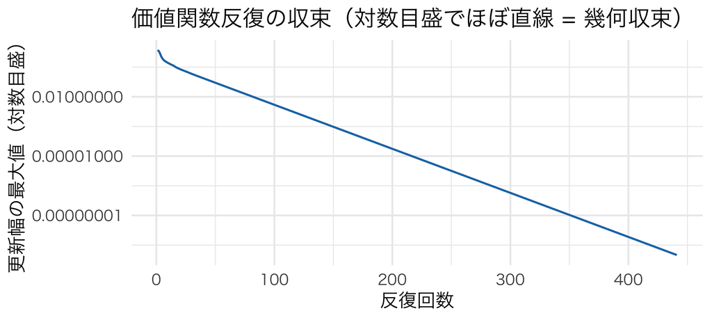

図 1

- 収束までの反復数：441 回。更新幅の比は $\beta = 0.95$ に近づく
- 縮小写像だから、どこから始めても同じ $V$ に着く

## 解けた方針：交換確率の S 字カーブ

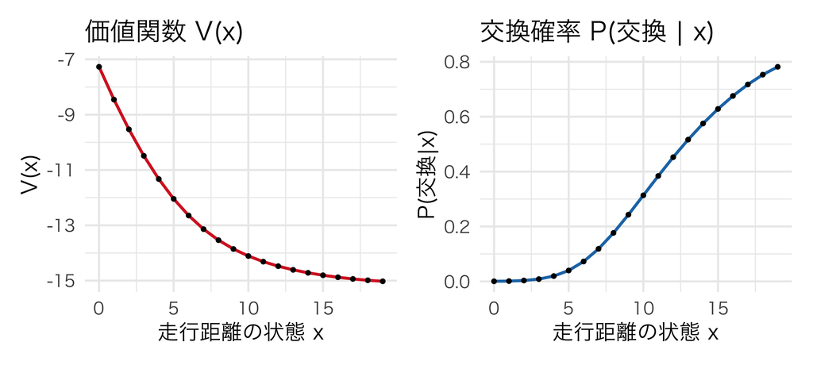

図 2

- 交換確率は $x = 0$ でほぼゼロ、$x = 19$ で約0.78 まで単調に上がる
- 「もう十分走った、そろそろ載せ替え」という直感が、**DP の解**として現れる

# データを生成する

## バス群のパネルシミュレーション

- **150台のバス × 80ヶ月**を追跡（burn-in 50期を捨てて定常付近から観測）
- 各期、各バスは状態 $x$ を見て、交換確率 $P(1 \mid x)$ に従って交換するか決める
- 観測されるのは $(x_{it}, a_{it})$ のみ。全体の交換率は 0.095
- 実データの分析者は $\theta_1$ も $RC$ も知らない。**それを復元するのが仕事**

## replacement cycle：のこぎり歯のパターン

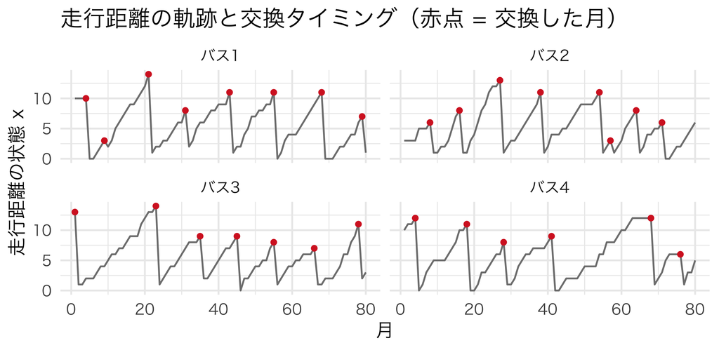

図 3

距離がじわじわ伸びては、交換でストンと0付近に戻る。これが Zurcher の台帳に相当する観測データ。

## 状態ごとの交換頻度：CCP の素材

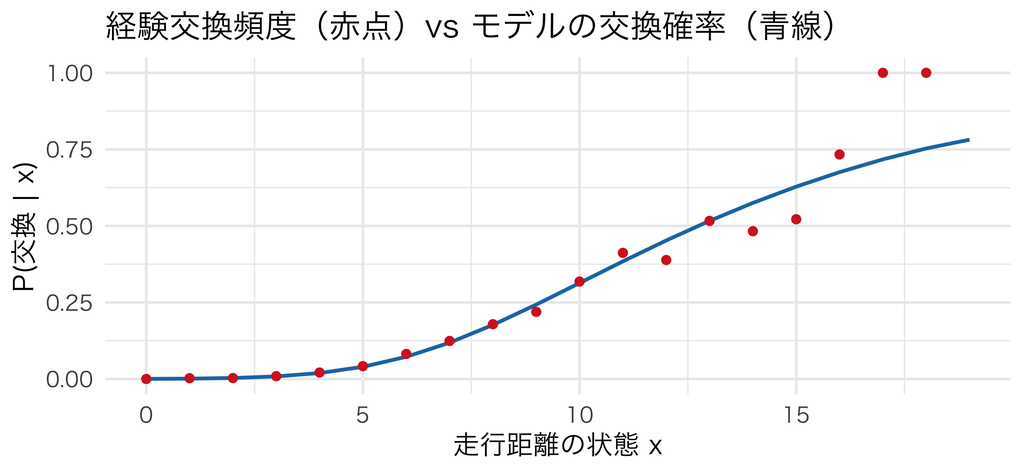

図 4

- 経験頻度はモデルの CCP とよく一致。ただし高走行距離はデータが薄くガタつく
- この「状態ごとの頻度」が、後半の **Hotz-Miller 推定の入力**になる

# 推定1：NFXP（Rust の方法）

## NFXP：入れ子の二重ループ

**Nested Fixed Point algorithm**。名前は仰々しいが構造はシンプル：

- **外側**：最適化アルゴリズムが $\theta = (\theta_1, RC)$ を提案する
- **内側**：その $\theta$ で価値関数反復を**解き切り**、$v(x, 0), v(x, 1)$ を得る
- その $v$ から logit 尤度を計算して外側に返す。外側は尤度を最大化する $\theta$ を探す

キモ：**外側が $\theta$ を1回動かすたびに、内側で DP が丸ごと1回走る**

## 対数尤度：第2回とまったく同じ形

各バス・各月について「実際にとった行動の確率の対数」を足し上げる：

$$\ell(\theta) = \sum_{i} \sum_{t} \left[ a_{it} \log P(1 \mid x_{it}; \theta) + (1 - a_{it}) \log P(0 \mid x_{it}; \theta) \right]$$

- $P(a \mid x; \theta)$ は logit（CCP）。ただしその中身の $v(x, a)$ は **DP を解かないと出てこない**
- 「選んだ行動の log 確率の合計」——第2回の MNL 尤度と同じ発想

## 負の対数尤度：内側で DP を解き切る

```r
neg_loglik_nfxp <- function(theta, X, A) {
  theta1 <- theta[1]; RC <- theta[2]
  if (theta1 <= 0 || RC <= 0) return(1e10)
  sol <- solve_vfi(theta1, RC, tol = 1e-8, maxit = 1000)  # ここで毎回 DP を解く
  m   <- pmax(sol$v0, sol$v1)
  lae <- m + log(exp(sol$v0 - m) + exp(sol$v1 - m))       # log(exp v0 + exp v1)
  logp1 <- sol$v1 - lae     # log P(交換|x)
  logp0 <- sol$v0 - lae     # log P(維持|x)
  xr <- as.vector(X) + 1
  ar <- as.vector(A)
  -sum(ifelse(ar == 1L, logp1[xr], logp0[xr]))
}
```

数式をそのまま書いただけ。`optim()` は最小化するので負の対数尤度を返す（第2回の型）。

## 真値回収の確認（SE は Hessian から）

| パラメータ | 真値 | 推定値 | SE | 95%CI下限 | 95%CI上限 |
| --- | --- | --- | --- | --- | --- |
| theta1（維持費の傾き） | 0.15 | 0.1414 | 0.0056 | 0.1304 | 0.1524 |
| RC（交換費） | 8.00 | 7.6128 | 0.2305 | 7.1610 | 8.0645 |

- 真値は 95%CI の中に回収される。動学モデルでも「真値回収」の作法は変わらない
- SE は `optim(hessian = TRUE)` の Hessian の逆行列から（第2回と同じ）

## NFXP の重さ：状態空間の呪い

- 今回の実行時間：約 0.3 秒（$K = 20$ 状態、たった2パラメータでこれ）
- 外側の評価1回ごとに、内側で価値関数反復が丸ごと1回走る

現実の問題で走行距離、ブランド、在庫、競合価格などを状態に含めると、その組合せが増えて計算負担が大きくなる。これを「**状態空間の呪い（curse of dimensionality）**」という。次のCCPアプローチは、推定のたびに価値関数を解く負担を減らす方法である。

# 推定2：Hotz-Miller の CCP

## 逆転の発想：価値関数を解かない

NFXP の重さの正体 =「価値関数を毎回解いている」こと。Hotz and Miller (1993) の一手：

> 価値関数を解かずに、**データの選択確率（CCP）から価値の差を逆算する**

二値選択では、logit の反転から：

$$\log P(1 \mid x) - \log P(0 \mid x) = v(x, 1) - v(x, 0)$$

- 左辺はデータの頻度から推定できる → 右辺の**価値差**が、DP を解かずに手に入る
- だが $v(x,1) - v(x,0)$ にはまだ**将来項** $\beta E[V(x') \mid x, a]$ の差が残っている……

## 交換は renewal action

思い出そう：**交換すると、状態は現在の $x$ によらず $x = 0$ にリセットされる**（$P_1$ の全行が同じ）

- これを **renewal action（更新行動）** と呼ぶ
- 交換を選んだ後の将来は、「今どこにいたか」を**忘れる**
- だから交換経由で書いた将来価値は、$x$ によらない**定数**を含む形になる
- この定数が、価値差をとるときに**綺麗に消える**——**finite dependence（有限依存）**

## Hotz-Miller の反転恒等式

T1EV のもとでは、logsum と logit を組み合わせると、任意の行動 $a$ について：

$$V(x) = v(x, a) + \gamma - \log P(a \mid x)$$

- **価値関数が「CCP で書ける」**——これが Hotz-Miller の核心の恒等式（導出はノートの callout 参照）
- 次期状態 $x'$ でこれを $a = 1$（交換）で使うと、renewal のおかげで $v(x', 1)$ の将来項が定数化：
- $V(x') = \mathrm{const} - \log P(1 \mid x')$ という形になる

## finite dependence：将来項が消えて回帰になる

将来項に代入して差をとると、定数が消えて $V$ が完全に消える。残る式：

$$y(x) = \log P(1 \mid x) - \log P(0 \mid x) + \beta \sum_{x'} \left( P_1(x' \mid x) - P_0(x' \mid x) \right) \log P(1 \mid x')$$

この $y(x)$（データから計算できる）が、flow utility の差に一致する：

$$y(x) = \theta_1 x - RC$$

**$y(x)$ を $x$ に回帰するだけ。傾きが $\theta_1$、切片が $-RC$。** VFI も optim も不要。

## 検算：真の CCP で恒等式を確かめる

まず、DP を解いて得た**真の CCP** を左辺に入れて、導出が正しいか確認する。

| 検算項目 | 値 |
| --- | --- |
| 恒等式の最大誤差 | 2.66e-15 |
| 回帰の傾き（theta1、真値 0.15） | 0.150000 |
| 回帰の切片の符号反転（RC、真値 8.0） | 8.000000 |

今回の設定で恒等式の数値誤差はほぼ機械精度に収まり、真値が復元された。導出した式と実装が整合している。

## 実践：データの頻度 CCP で推定する

```r
n_x  <- sapply(0:(K - 1), function(xv) sum(X == xv))     # 状態ごとの観測数
n1_x <- sapply(0:(K - 1), function(xv) sum(A[X == xv]))  # 状態ごとの交換数
Psm  <- (n1_x + 0.5) / (n_x + 1.0)          # Jeffreys/add-half 平滑化
logP1h <- log(Psm); logP0h <- log(1 - Psm)
logP1h_full <- logP1h
observed_idx <- which(n_x > 0)
if (length(observed_idx) == 0) stop("CCPを計算できる観測状態がない")
for (idx in which(n_x == 0)) {
  nearest <- observed_idx[which.min(abs(observed_idx - idx))]
  logP1h_full[idx] <- logP1h[nearest]
}
y_hat <- logP1h - logP0h + beta * as.vector(diffP %*% logP1h_full)
good  <- n_x >= 30                           # データの厚い状態だけ使う
fit_ccp <- lm(y_hat ~ xs, weights = n_x, subset = good)   # ただの回帰（WLS）
theta1_ccp <- as.numeric(coef(fit_ccp)[2])
RC_ccp     <- as.numeric(-coef(fit_ccp)[1])
round(c(theta1 = theta1_ccp, RC = RC_ccp), 4)
```

```
theta1     RC
0.1181 6.8942
```

## NFXP vs CCP：推定値と計算時間

| 手法 | theta1 | RC | 時間（秒） | DP を解くか |
| --- | --- | --- | --- | --- |
| NFXP (Rust) | 0.1414 | 7.6128 | 0.342 | 毎評価で解き切る |
| CCP (Hotz-Miller) | 0.1181 | 6.8942 | 0.000 | 一度も解かない |

## 速さと精度のトレードオフ

- **NFXP**：外側の最適化 × 内側の価値関数反復。正しく指定されたfull-solution MLEだが、状態空間が大きいと重い
- **CCP**：今回のrenewal構造では、頻度CCPと遷移確率から将来項を消去し、回帰で推定できる。推定時にDPを解かないため計算負担が小さい
- Hotz–Millerは条件下で一致性・漸近正規性。NFXPと同じ推定量・同じ漸近分散という意味ではない
- 単純2段階は第一段階ノイズを受ける。NPLなどの反復で改善できる

# 識別と反実仮想

## 割引因子はなぜ推定せず固定するのか

- 「早めに交換する」行動の理由は2通りに読める：
  - 交換費 $RC$ が安いから（flow utility の形）
  - $\beta$ が大きく、将来の維持費を強く恐れているから（先読みの強さ）
- この2つは選択データだけからは**もつれて分離しにくい** → $\beta$ の識別は一般に困難
- 実務の慣習：金利や意思決定の頻度から $\beta$ を**外から与えて固定**（今日は 0.95）
- 効用の水準にも意味はなく、正規化が要る（静学の outside option = 0 と同じ）

## 反実仮想：交換費を20%補助したら

問い：**交換費 $RC$ を20%補助したら、交換頻度と平均走行距離はどう変わるか**（データには無い世界）

| 政策 | 長期交換率 | 平均走行距離 |
| --- | --- | --- |
| 補助前（RC = 8.0） | 0.0934 | 5.098 |
| 補助後（RC = 6.4） | 0.1098 | 4.478 |

- 手順：$RC$ を $0.8 \times RC$ に置き換えて **DP を解き直し**、新しい方針の定常分布で長期の値を計算
- 交換率は約 17.6%、平均走行距離は約 -12.2% 変化

## 補助の効果：定常分布が若返る

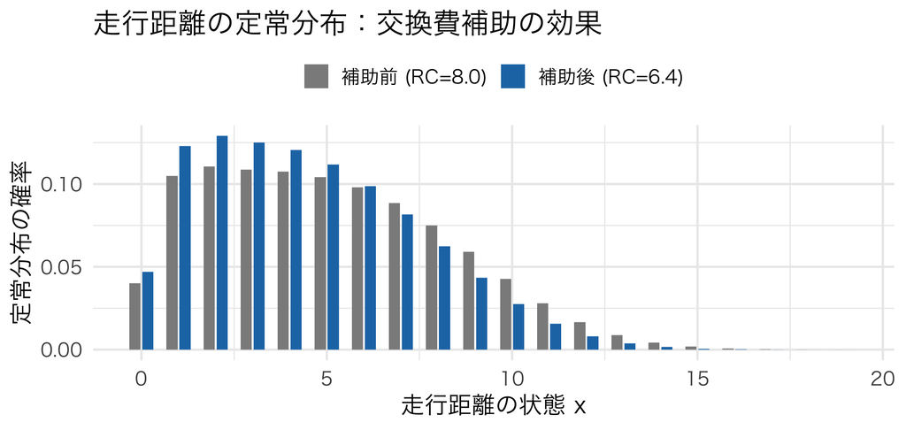

図 5

交換が安くなったので、より頻繁に・より若いうちに載せ替える。フリート全体が低走行距離側に寄る。

## もし myopic（近視眼的）で推定したら

分析者が誤って「消費者は将来を見ない」と仮定し、$\beta = 0$（＝ただの静学 logit）で推定すると：

| モデル | theta1 | RC |
| --- | --- | --- |
| 真値 | 0.1500 | 8.0000 |
| 動学（beta = 0.95、正しい） | 0.1486 | 7.9501 |
| myopic（beta = 0、誤り） | 0.4553 | 5.4102 |

- この数値例では、myopic は $\theta_1$ を**3倍近くに過大推定**する
- 「将来の維持費を恐れて早めに交換」の分まで、**flow utility の傾きに押し付ける**しかないから

## myopic は反実仮想も外す

歪んだパラメータで同じ補助（$RC$ を20%減）を予測させると：

| 分析者 | 補助前の交換率 | 補助後の交換率 | 変化率（%） |
| --- | --- | --- | --- |
| 正しい動学（beta = 0.95） | 0.0934 | 0.1098 | 17.6 |
| myopic（beta = 0、誤り） | 0.0943 | 0.1246 | 32.1 |

- この数値例では、正しい動学モデルは交換率が約18%増えると予測し、myopicはその効果をおよそ2倍に過大評価する
- **深層パラメータを間違えれば、その先の政策予測も間違える**

## 実務指針：動学が要るかは「問いが状態を動かすか」

- **静学で足りる問い**：今の価格・属性への反応、直近の代替パターン → logit / BLP（第2〜4回）で十分。速いし識別も素直
- **動学が要る問い**：反実仮想が「状態」を動かすもの——在庫、契約残期間、走行距離、ポイント残高、保有年数
- 棚の値付けなら静学、解約金の設計や買いだめ誘発なら動学
- コスト：状態空間の呪い、$\beta$ の識別、モデル誤設定リスク（myopic はその極端な例）

# まとめ

## この回の要点

- 動学的離散選択の部品：状態 $x$・行動 $a$・遷移 $P(x' \mid x, a)$・$v(x, a)$・$V(x)$・Bellman 方程式
- T1EV なら動学でも **Emax = logsum、選択確率 = logit**。静学の $\delta$ の座に $v(x, a)$ が座るだけ
- 今回のBellman作用素は $\beta$ を縮小係数とする**縮小写像**であり、価値関数反復が収束する
- **NFXP**：外側最適化 × 内側 VFIのfull-solution MLE。**CCP**：Hotz–Millerの反転 + renewal actionのfinite dependenceで回帰1本。条件下で一致・漸近正規だが、単純2段階には第一段階ノイズ
- この例の反実仮想：交換費20%補助で交換率は約18%増える。myopic推定では $\theta_1$ が約3倍となり、補助の効果を約2倍に過大評価する

## 宿題

- **状態空間の呪いを体感**：`K <- 20` を `K <- 100` に変えて、VFI の反復数・実行時間、NFXP と CCP の速度差がどう開くか観察する
- **CCP のノイズを見る**：seed を変えて CCP 推定を5回繰り返し、$(\theta_1, RC)$ のばらつきを NFXP と比べる
- 生成AIに「動学的離散選択モデルで割引因子が識別しにくいのはなぜか」と聞いて、今日の説明（$\beta$ と flow utility がもつれる）と比べる
- **coding課題は `assignment13.qmd`**：縮小版 Rust モデルを自作し、NFXP と CCP を両方実装、補助の反実仮想を動学と myopic で比較する

## 次回予告：動学を消費者パネルへ

- 今日は「一人の意思決定者（Zurcher）」。次回は**多数の消費者の購買履歴**を異質性と状態依存に分けて考える
- **state dependence**：過去に買ったブランドを今日も選びやすい（ロイヤルティ・習慣）
- **買いだめ（stockpiling）**：特売のまとめ買いで「在庫」という状態が上がり、しばらく買わなくなる
- 「特売で売上が増えた」の一部は、実は**将来需要の先食い**かもしれない——それを見抜く道具が今日の DP

**Reading**：Rust (1987)、Hotz and Miller (1993)、Aguirregabiria and Mira (2010)